# Lab 2: Probability Theory

R script for question 4e to 4i

# 4. Circles, Random Samples, and the Central Limit Theorem

## e. Now let $n=100$. Use R to simulate a draw for $X_1, X_2,...,X_n$ and $Y_1,Y_2,...,Y_n$. Calculate the resulting values for $D_1, D_2,...D_n$. Create a plot to visualize your draws, with $X$ on one axis and $Y$ on the other. We suggest using a command like the following to assign a different color to each point, based on whether it falls inside the unit circle or outside it. Note that we pass $d+1$ instead of $d$ into the color argument because 0 corresponds to the color white.

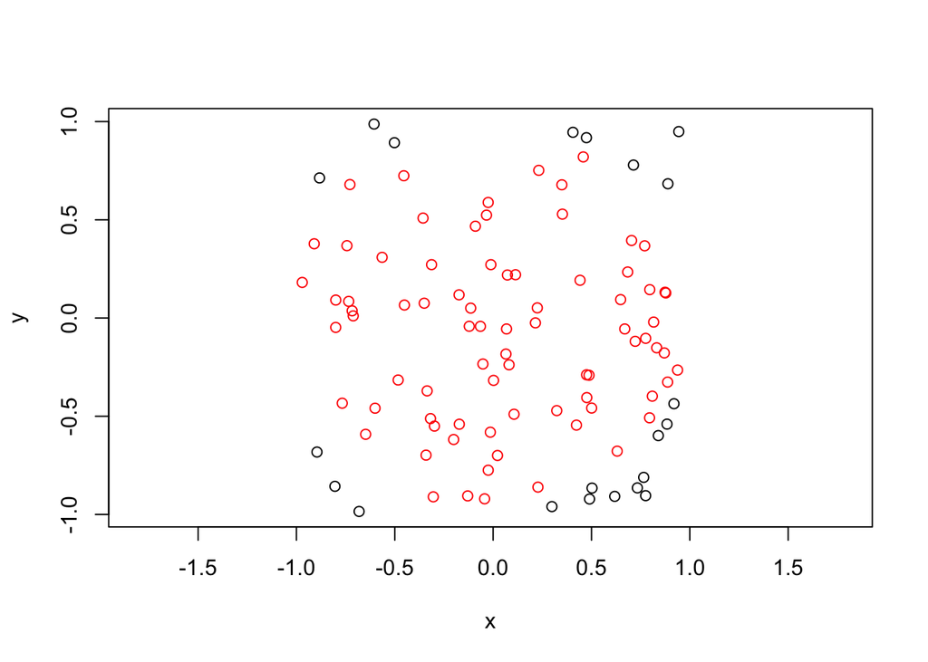

```r
# (Atit) Answer to question 4e:

# Set the number of simulation
n <- 100


# Generate random draws from a uniform distribution with range [-1,1]
# for both the r.v. X and the r.v. Y.
x <- runif(n, min=-1, max=1)
y <- runif(n, min=-1, max=1)


# Calculate the r.v. D.
d <- ifelse((x^2 + y^2) < 1, 1, 0)


# Plot X, Y, and D
plot(x,y, col=d+1, asp=1)
```

## f. What value do you get for the sample average, $\bar{D}$? How does it compare to your answer for part a?

### (Atit) Answer to question 4f:

### The sample average, $\bar{D}$ is:

```r
# Calculate mean of D
mean(d)
```

```
## [1] 0.79
```

### The expected value of D from 4a is pi/4:

```r
# Calculate mean of D
pi/4
```

```
## [1] 0.7853982
```

### The value is a bit different.

## g. Now use R to replicate the previous experiment 10,000 times, generating a sample average of the $D_i$ each time. Plot a histogram of the sample averages.

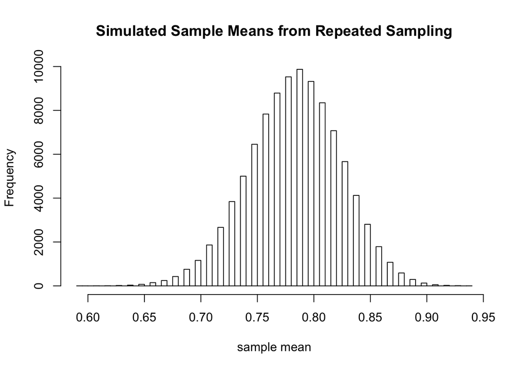

```r
#####################################################################
# Setup a function to generate a vector of D

simulate_d = function(n){

# Generate random draws from a uniform distribution with range [-1,1]
# for both the r.v. X and the r.v. Y.
x <- runif(n, min=-1, max=1)
y <- runif(n, min=-1, max=1)


# Calculate the r.v. D.
sim_d <- ifelse((x^2 + y^2) < 1, 1, 0)

return(sim_d)
}

rep_d <- replicate(100000,mean(simulate_d(n)))


# Plot the histogram of the simulated sample means
hist(rep_d, breaks = 50, main = "Simulated Sample Means from Repeated Sampling",
     xlab = "sample mean")
```

## h. Compute the standard deviation of your sample averages to see if it’s close to the value you expect from part c.

### (Atit) Answer to question 4h:

```r
# Compute standard deviation of the sample averages:
sd(rep_d)
```

```
## [1] 0.04099851
```

### This value is close the what is computed in 4c which was ~ 0.4105 / sqrt(100) = 0.04105.

## i. Compute the fraction of your sample averages that are larger that $3/4$ to see if it’s close to the value you expect from part d.

### (Atit) Answer to question 4i:

```r
# Compute the fraction of thhe sample averages that are larger than 3/4:
sum(rep_d[rep_d > 0.75])/sum(rep_d)
```

```
## [1] 0.7891551
```

### This value is close the what is computed in 4d which was 0.8057.